# Test some numerical methods on a stiff scalar problem

[AMath 586, Spring Quarter 2019](http://staff.washington.edu/rjl/classes/am586s2019/) at the University of Washington. For other notebooks, see Index.html or the [Index of all notebooks on Github](https://github.com/rjleveque/amath586s2019/blob/master/notebooks/Index.html).

This notebook shows the numerical solution to the ODE

$$ u'(t) = \lambda(u(t)-\cos(t)) - \sin(t), \qquad u(t_0) = \eta $$

as $t_0, \eta,$ and $\lambda$ are varied. This ODE is used in Examples 8.3 of [the textbook](http://staff.washington.edu/rjl/fdmbook/) to illustrate the need for L-stable methods.

The exact solution is

$$ u(t) = \cos(t) + \exp(\lambda(t-t_0))(\eta - \cos(t_0)). $$

Note in particular that if $u(0)=1$ is specified then the solution is just $u(t)=\cos(t)$ and if $\lambda=0$ then other solutions remain parallel to this, since in this case the ODE $u'(t)=-\sin(t)$ has solution $u(t) = \cos(t) + (\eta - \cos(t_0))$. Note that in this case $f(u,t)$ is independent of $u$ and the ODE can be solved by simple integration.

If $\lambda<0$ then solutions decay towards this "slow solution". This equation exhibits *stiffness* when $\lambda$ is very negative and we wish to compute the solution for over times that are long relative to $-1/\lambda$.

This exact solution is explored in the notebook ScalarStiffness.html.

```python
%matplotlib inline
```

```python
from pylab import *
from ipywidgets import interact, IntSlider, FloatSlider
```

```python
tfinal = 6*pi
def utrue(t0, eta, lam):
    t = linspace(t0,tfinal,1000)
    u = cos(t) + exp(lam*(t-t0))*(eta - cos(t0))
    return t,u
```

## Forward Euler

```python
def forward_euler(nsteps, eta, lam):
    from scipy.optimize import fsolve

    f = lambda u,t: lam*(u-cos(t)) - sin(t)
    t = linspace(0, tfinal, nsteps+1)
    dt = t[1] - t[0]
    U = empty((nsteps+1))  # array for computed solution
    U[0] = eta

    for n in range(nsteps):
        Un = U[n]
        tn = t[n]
        U[n+1] = Un + dt*f(Un, tn)

    figure(figsize=(10,4))
    axis([-1,tfinal, -3,3])
    tfine,ufine = utrue(0., eta, lam)
    plot(tfine, ufine, 'k', label='true solution')
    plot(t, U, 'bo-', label='Forward Euler')
    legend(loc='lower right')
    title('Forward Euler method with $k = %g, \lambda = %g, \quad k\lambda = %g$' \
          % (dt,lam, dt*lam))
```

Forward Euler is absolutely stable only if $-2 \leq k\lambda \leq 0$. Here's a case where it is barely stable. It looks ok if the initial data is $u(0) = 1$ so there is no rapid transient in the true solution, and because the time step is small enough that the one-step errors introduced are not too large:

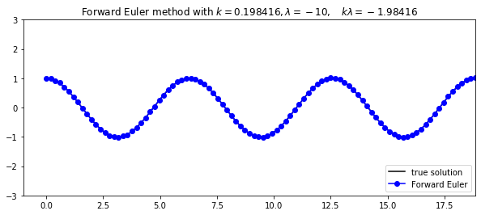

```python
forward_euler(nsteps=95, eta=1, lam=-10)
```

But if we solve the equation with the initial condition $u(0) = 0$, giving a rapid transient in the true solution, then the near-instability is apparent:

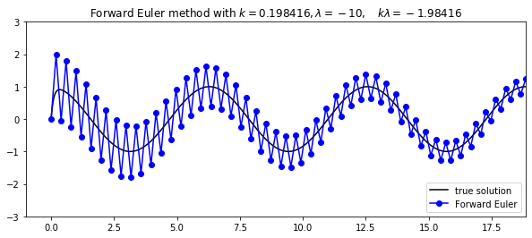

```python
forward_euler(nsteps=95, eta=0, lam=-10)
```

With a slightly larger timestep it goes unstable and the numerical solution grows exponentially:

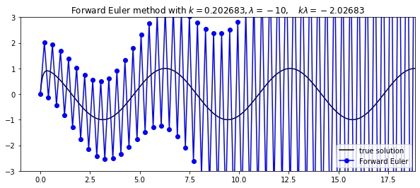

```python
forward_euler(nsteps=93, eta=0, lam=-10)
```

## Trapezoidal method

Next we implement the Trapezoidal method on this same problem.

```python
def trapezoid(nsteps, eta, lam):
    from scipy.optimize import fsolve

    f = lambda u,t: lam*(u-cos(t)) - sin(t)
    t = linspace(0, tfinal, nsteps+1)
    dt = t[1] - t[0]
    U = empty((nsteps+1))  # array for computed solution
    U[0] = eta

    for n in range(nsteps):
        Un = U[n]
        tn = t[n]
        tnp = t[n+1]
        g = lambda u: u - Un - 0.5*dt*f(Un,tn) - 0.5*dt*f(u,tnp)
        Unp = fsolve(g, Un)
        U[n+1] = Unp

    figure(figsize=(10,4))
    axis([-1,tfinal, -3,3])
    tfine,ufine = utrue(0., eta, lam)
    plot(tfine, ufine, 'k', label='true solution')
    plot(t, U, 'bo-', label='Trapezoid')
    legend(loc='lower right')
    title('Trapezoid method with $k = %g, \lambda = %g, \quad k\lambda = %g$' \
          % (dt,lam, dt*lam))
```

This method does much better with the parameters we used above for Forward Euler:

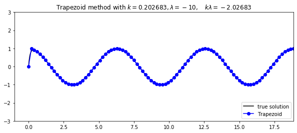

```python
trapezoid(nsteps=93, eta=0, lam=-10)
```

The Trapezoid method is A-stable and remains stable even when $k\lambda \rightarrow -\infty$. But it is not L-stable, and $R(z) \rightarrow -1$ as $|z| \rightarrow \infty$. Hence if $|k\lambda|$ is very large we expect that a rapid transient will not be damped but rather will oscillate:

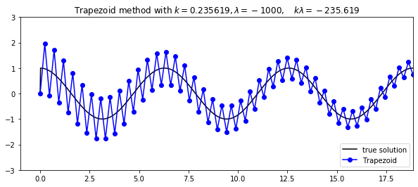

```python
trapezoid(nsteps=80, eta=0, lam=-1000)
```

Backward Euler or the second-order accurate TR-BDF2 method would both do better in this case, since they are L-stable.

```python
def tr_bdf2(nsteps, eta, lam):
    from scipy.optimize import fsolve

    f = lambda u,t: lam*(u-cos(t)) - sin(t)
    t = linspace(0, tfinal, nsteps+1)
    dt = t[1] - t[0]
    U = empty((nsteps+1))  # array for computed solution
    U[0] = eta

    for n in range(nsteps):
        Un = U[n]
        tn = t[n]
        tnp = t[n+1]
        tnph = 0.5*(t[n] + t[n+1])  # half time step
        g1 = lambda u: u - Un - 0.25*dt*f(Un,tn) - 0.25*dt*f(u,tnph)
        Ustar = fsolve(g1, Un)
        g2 = lambda u: u - 4/3*Ustar + 1/3*Un - 1/3*dt*f(u,tnp)
        Unp = fsolve(g2, Ustar)
        U[n+1] = Unp

    figure(figsize=(10,4))
    axis([-1,tfinal, -3,3])
    tfine,ufine = utrue(0., eta, lam)
    plot(tfine, ufine, 'k', label='true solution')
    plot(t, U, 'bo-', label='TR-BDF2')
    legend(loc='lower right')
    title('TR-BDF2 method with $k = %g, \lambda = %g, \quad k\lambda = %g$' \
          % (dt,lam, dt*lam))
```

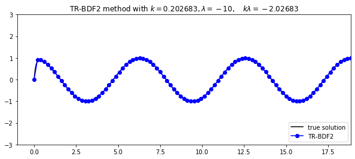

```python
tr_bdf2(nsteps=93, eta=0, lam=-10)
```

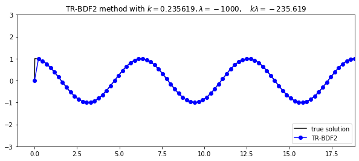

```python
tr_bdf2(nsteps=80, eta=0, lam=-1000)
```